# wk6d2 homework

# Q1

```r
library(tidyverse)
library(skimr)
```

```r
phone_reviews <- read_csv("data/20190928-items.csv") %>%
  janitor::clean_names()
```

```r
skim(phone_reviews)
```

```
── Data Summary ────────────────────────
                           Values
Name                       phone_reviews
Number of rows             792
Number of columns          9
_______________________
Column type frequency:
  character                7
  numeric                  2
________________________
Group variables            None
```

|  | skim_variable | n_missing | complete_rate | min | max | empty | n_unique | whitespace |
| --- | --- | --- | --- | --- | --- | --- | --- | --- |
| 1 | asin | 0 | 1.0000000 | 10 | 10 | 0 | 792 | 0 |
| 2 | brand | 0 | 1.0000000 | 4 | 8 | 0 | 10 | 0 |
| 3 | title | 0 | 1.0000000 | 19 | 200 | 0 | 785 | 0 |
| 4 | url | 0 | 1.0000000 | 60 | 97 | 0 | 792 | 0 |
| 5 | image | 0 | 1.0000000 | 87 | 87 | 0 | 719 | 0 |
| 6 | review_url | 0 | 1.0000000 | 49 | 49 | 0 | 792 | 0 |
| 7 | prices | 215 | 0.7285354 | 6 | 19 | 0 | 447 | 0 |

|  | skim_variable | n_missing | complete_rate | mean | sd | p0 | p25 | p50 | p75 | p100 | hist |
| --- | --- | --- | --- | --- | --- | --- | --- | --- | --- | --- | --- |
| 1 | rating | 0 | 1 | 3.607576 | 0.6687295 | 1 | 3.2 | 3.7 | 4.00 | 5 | ▁▁▅▇▂ |
| 2 | total_reviews | 0 | 1 | 104.231061 | 166.2425030 | 1 | 7.0 | 31.5 | 122.25 | 984 | ▇▁▁▁▁ |

[output not shown]

Some visualizations:

## Rating

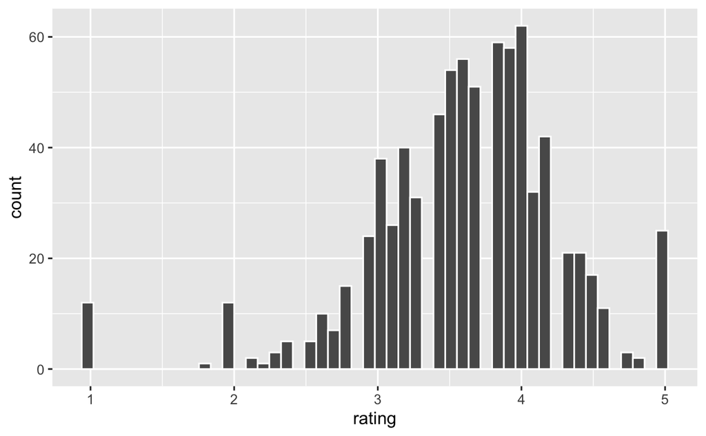

```r
phone_reviews %>%
  ggplot() +
  geom_histogram(aes(x = rating), colour = "white", bins = 50)
```

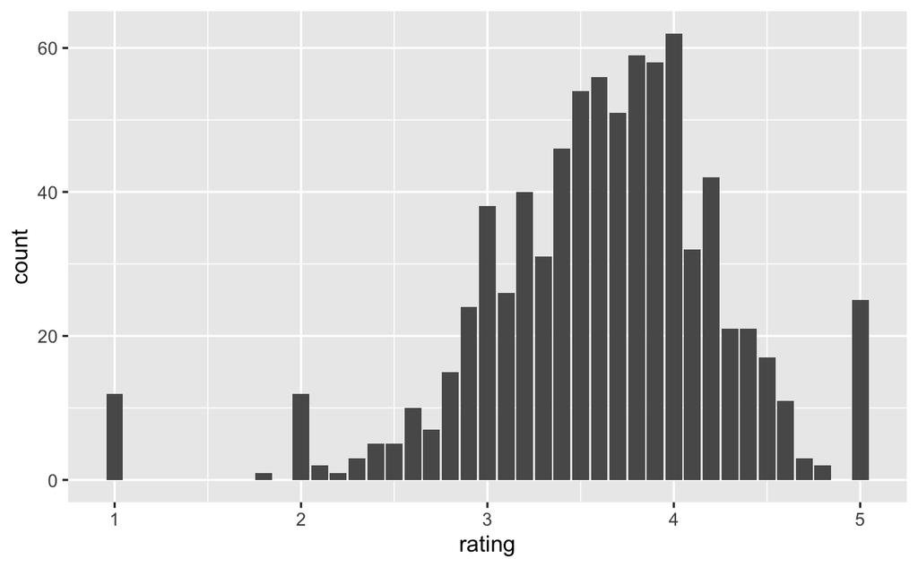

```r
phone_reviews %>%
  ggplot() +
  geom_bar(aes(x = rating))
```

Discrete ordinal or continuous? Ratings are from 1 to 5 (from skim) in increments of 0.1 so maybe discrete numeric. Looks negatively skewed.

## Total reviews

Skim: min is 1, max is 984. The mean and median values and histogram in skim indicate positively skewed data.

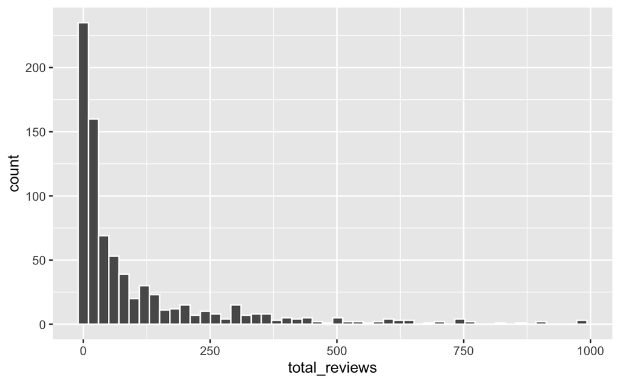

```r
phone_reviews %>%
  ggplot() +
  geom_histogram(aes(x = total_reviews), colour = "white", bins = 50)
```

Looks very positively skewed.

```r
phone_reviews %>%
  summarise(skewness = e1071::skewness(total_reviews, type = 1))
```

| skewness |
| --- |
| 2.549505 |

Skewness coefficient shows it is highly positively skewed.

## Prices

Entered as data, min 6, max 19, lots of NAs. Inspecting the data, these are entered as $ values, and the min/max here does not indicate min and max prices. Would need to clean data to inspect.

# Q2

Discrete values

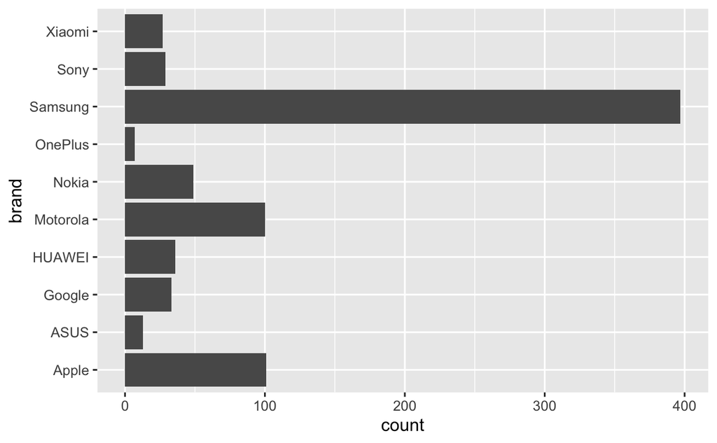

```r
# brand
phone_reviews %>%
  ggplot() +
  geom_bar(aes(y=brand))
```

**Samsung** is the brand with the most entries in this data.

Confirming this:

```r
phone_reviews %>%
  group_by(brand) %>%
  summarise(count = n()) %>%
  slice_max(order_by = count)
```

| brand | count |
| --- | --- |
| Samsung | 397 |

# Q3

For your top brand, plot the distribution of phone ratings as a probability density, overlaying a fitted normal distribution. Do you think the normal distribution provides a good model of these ratings?

- filter for brand == samsung
- find mean and sd
- plot ratings as pdf: use geom_histogram with y = after_stat(density)
- add to plot using stat_function dnorm with Samsung rating mean and sd
- check: is 68% data within 1 sd of mean? is 95% within 2 sd? is 99.7% within 3 sd?

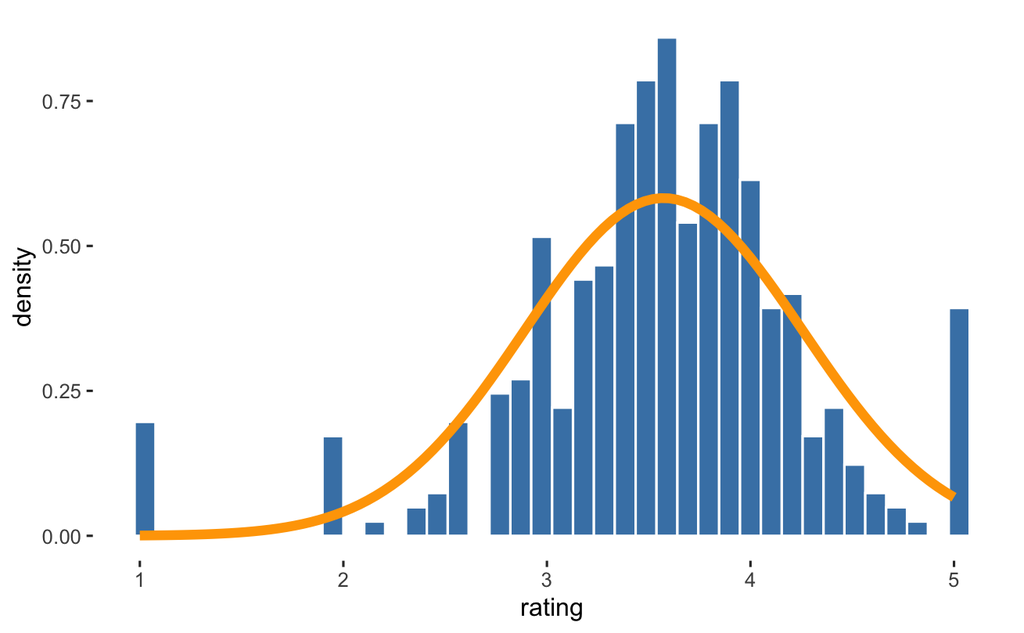

```r
# find mean and sd for Samsung ratings
Samsung_rating_stats <- phone_reviews %>%
  filter(brand == "Samsung") %>%
  summarise(mean = mean(rating),
            sd = sd(rating))

# plot pdf
phone_reviews %>%
  filter(brand == "Samsung") %>%
  ggplot() +
  geom_histogram(aes(x = rating, y = after_stat(density)),
                 colour = "white", fill = "steelblue", bins = 40) +
  stat_function(
    fun = dnorm,
    args = list(
      mean = Samsung_rating_stats$mean,
      sd = Samsung_rating_stats$sd
    ),
    colour = "orange", size = 2
  ) +
  theme(panel.background = element_rect(fill = "white"))
```

```r
NA
```

The normal distribution line looks kind of ok, although there are plenty of bars above and below the curve, and the extreme values (1 and 5) aren’t really captured.

# Q4

Let’s see if the data fits the three-sigma rule:

- check: is 68% data within 1 sd of mean? is 95% within 2 sd? is 99.7% within 3 sd?

```r
# set up values to check percentages
max_1sd <- Samsung_rating_stats$mean + Samsung_rating_stats$sd
min_1sd <- Samsung_rating_stats$mean - Samsung_rating_stats$sd

max_2sd <- Samsung_rating_stats$mean + (2*Samsung_rating_stats$sd)
min_2sd <- Samsung_rating_stats$mean - (2*Samsung_rating_stats$sd)

max_3sd <- Samsung_rating_stats$mean + (3*Samsung_rating_stats$sd)
min_3sd <- Samsung_rating_stats$mean - (3*Samsung_rating_stats$sd)

Samsung_rating_stats$mean
```

```
[1] 3.5733
```

```r
Samsung_rating_stats$sd
```

```
[1] 0.6847859
```

```r
max_1sd
```

```
[1] 4.258086
```

```r
min_1sd
```

```
[1] 2.888514
```

```r
max_2sd
```

```
[1] 4.942872
```

```r
min_2sd
```

```
[1] 2.203728
```

```r
max_3sd
```

```
[1] 5.627658
```

```r
min_3sd
```

```
[1] 1.518942
```

```r
# check proportion of data within these ranges

# within 1 sd
prop_1sd <- phone_reviews %>%
  filter(brand == "Samsung") %>%
  filter(rating >= min_1sd & rating <= max_1sd) %>% # 315 rows
  summarise(prop = n() / nrow(phone_reviews %>%
                                filter(brand == "Samsung"))) %>% # total 397 rows
  pull(prop)

# within 2 sd
prop_2sd <- phone_reviews %>%
  filter(brand == "Samsung") %>%
  filter(rating >= min_2sd & rating <= max_2sd) %>% # 365 rows
  summarise(prop = n() / nrow(phone_reviews %>%
                                filter(brand == "Samsung"))) %>% # total 397 rows
  pull(prop)

# within 3 sd
prop_3sd <- phone_reviews %>%
  filter(brand == "Samsung") %>%
  filter(rating >= min_3sd & rating <= max_3sd) %>% # 389 rows
  summarise(prop = n() / nrow(phone_reviews %>%
                                filter(brand == "Samsung"))) %>% # total 397 rows
  pull(prop)

prop_1sd
```

```
[1] 0.7934509
```

```r
prop_2sd
```

```
[1] 0.9193955
```

```r
prop_3sd
```

```
[1] 0.9798489
```

No way Jose is this normal. For normal, we would expect:

- ~67% of our data to be within 1sd, but here it is 79%
- ~95% to be within 2sd, but here it is 92%
- ~99.7% to be within 3sd, but here it is 98% of our data.

So our data is spread less broadly than a normal distribution. We might want to transform it in order to make it “standard normal”, i.e. scaling N[3.57,0.68] to N[0,1] using:

(x-3.57)/0.68

Let’s try this:

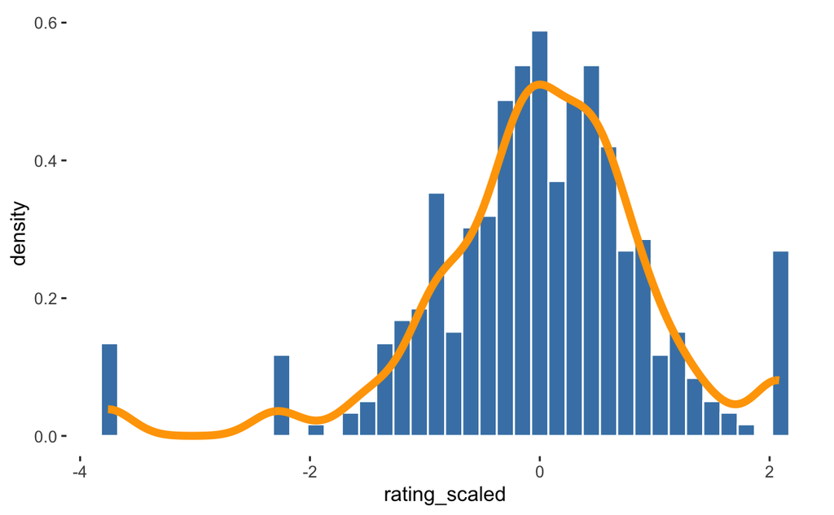

```r
Samsung_rating_scaled <- phone_reviews %>%
  filter(brand == "Samsung") %>%
  mutate(rating_scaled = ((rating - Samsung_rating_stats$mean)/Samsung_rating_stats$sd))

Samsung_rating_scaled %>%
  ggplot() +
  geom_histogram(aes(x = rating_scaled, y = after_stat(density)),
                 colour = "white", fill = "steelblue", bins = 40) +
  geom_smooth(aes(x = rating_scaled, y = after_stat(density)), stat = "density",
              colour = "orange", size = 2) +
  theme(panel.background = element_rect(fill = "white"))
```

# Extension

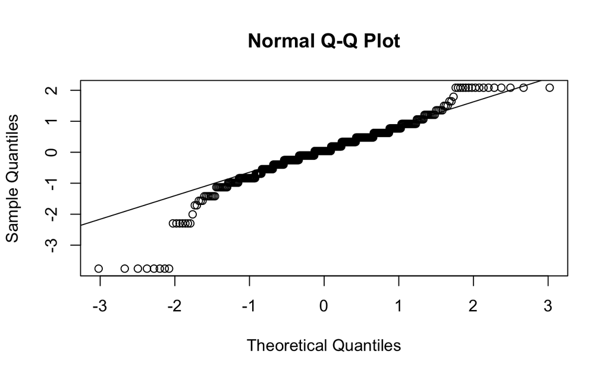

```r
Samsung_data <- phone_reviews %>%
  filter(brand == "Samsung")

# cannot pipe into it so first assign the filter data
# first run qqnorm
qqnorm(Samsung_rating_scaled$rating_scaled)
# then run qqline to get theoretical
qqline(Samsung_rating_scaled$rating_scaled)
```

This indicates the extreme rating values (e.g. rating 1 and 5) give a long tail, and lots of the rest of the data is concentrated in the middle.

Use rnorm to generate random numbers that are normally distributed

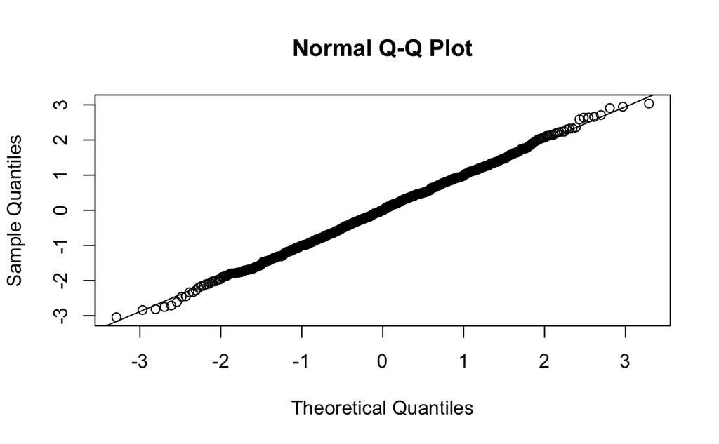

```r
qqnorm(rnorm(1000,0,1))
qqline(rnorm(1000,0,1))
```

Can also use this to see what samsung data should be if normally distributed

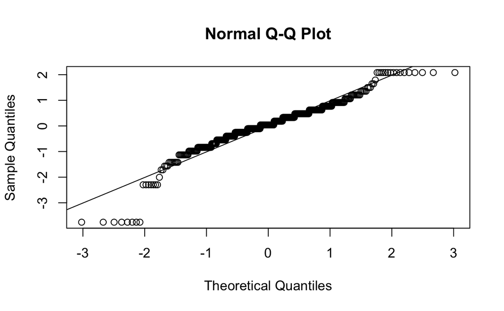

```r
qqnorm(Samsung_rating_scaled$rating_scaled)
qqline(rnorm(1000, mean(Samsung_rating_scaled$rating_scaled), sd(Samsung_rating_scaled$rating_scaled)))
```

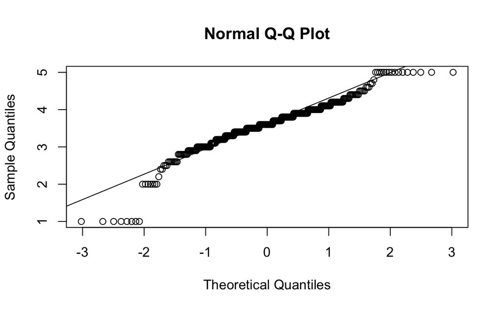

```r
qqnorm(Samsung_rating_scaled$rating)
qqline(rnorm(1000, mean(Samsung_rating_scaled$rating), sd(Samsung_rating_scaled$rating)))
```

This plot shows that our data looks fairly normal in the middle of the bell curve but the tails do not fit this, the extreme values of rating 1 and 5 do not fit with normal distribution.